# TAAC2026 Demo Dataset 数据分析

本 Notebook 用于分析 TAAC2026 竞赛的 Demo 数据集 (1000 条样本)

## 数据集概述

- **文件**: demo_1000.parquet
- **样本数**: 1,000
- **特征列**: 120
- **文件大小**: ~39 MB

## 特征分类

1. ID & Label (5列)
2. User Int Features (46列)
3. User Dense Features (10列)
4. Item Int Features (14列)
5. Domain Sequence Features (45列)

```python
# 导入必要的库
import pandas as pd
import numpy as np
import matplotlib.pyplot as plt
import seaborn as sns
from collections import Counter
import warnings
warnings.filterwarnings('ignore')

# 设置中文字体
plt.rcParams['font.sans-serif'] = ['SimHei', 'Arial Unicode MS', 'DejaVu Sans']
plt.rcParams['axes.unicode_minus'] = False

# 设置显示选项
pd.set_option('display.max_columns', None)
pd.set_option('display.width', None)
pd.set_option('display.max_colwidth', 50)

print("库导入完成！")
```

```
库导入完成！
```

## 1. 数据加载与基本信息

```python
# 读取 Parquet 文件
file_path = '/Users/huanglichen/Desktop/recommendation_sys/demo_1000.parquet'
df = pd.read_parquet(file_path)

print(f"数据集形状: {df.shape}")
print(f"\n列名列表 ({len(df.columns)} 列):")
print(df.columns.tolist())
```

```
数据集形状: (1000, 120)

列名列表 (120 列):
['user_id', 'item_id', 'label_type', 'label_time', 'timestamp', 'user_int_feats_1', 'user_int_feats_3', 'user_int_feats_4', 'user_int_feats_15', 'user_int_feats_48', 'user_int_feats_49', 'user_int_feats_50', 'user_int_feats_51', 'user_int_feats_52', 'user_int_feats_53', 'user_int_feats_54', 'user_in…
```

```python
# 查看数据类型
print("数据类型信息:")
print(df.dtypes.value_counts())
print("\n详细数据类型:")
for col in df.columns:
    print(f"{col}: {df[col].dtype}")
```

```
数据类型信息:
object     67
float64    47
int64       5
int32       1
Name: count, dtype: int64

详细数据类型:
user_id: int64
item_id: int64
label_type: int32
label_time: int64
timestamp: int64
user_int_feats_1: int64
user_int_feats_3: float64
user_int_feats_4: float64
user_int_feats_15: object
user_int_feats_48: float64
user_int_feats_49: float64
user_int_feats_50: float64
user_int_feats_51: float64
user_int_feats_52: float64
user_int_feats_53: float64
user_int_feats_54: float64
user_int_feats_55: float64
user_int_feats_56: float64
user_int_feats_57: float64
user_int_feats_58: float64
user_int_feats_59: float64
user_int_feats_60: object
user_int_feats_62: object
user_int_feats_63: object
user_int_feats_64: object
user_int_feats_65: object
user_int_feats_66: object
user_int_feats_80: object
user_int_feats_82: float64
user_int_feats_86: float64
user_int_feats_89: object
user_int_feats_90: object
```

[output cut: 73 more lines]

```
domain_c_seq_34: object
domain_c_seq_35: object
domain_c_seq_36: object
domain_c_seq_37: object
domain_c_seq_47: object
domain_d_seq_17: object
domain_d_seq_18: object
domain_d_seq_19: object
domain_d_seq_20: object
domain_d_seq_21: object
domain_d_seq_22: object
domain_d_seq_23: object
domain_d_seq_24: object
domain_d_seq_25: object
domain_d_seq_26: object
```

```python
# 查看前几行数据
print("前 3 行数据:")
df.head(3)
```

```
前 3 行数据:
```

|  | user_id | item_id | label_type | label_time | timestamp | user_int_feats_1 | user_int_feats_3 | user_int_feats_4 | user_int_feats_15 | user_int_feats_48 | user_int_feats_49 | user_int_feats_50 | user_int_feats_51 | user_int_feats_52 | user_int_feats_53 | user_int_feats_54 | user_int_feats_55 | user_int_feats_56 | user_int_feats_57 | user_int_feats_58 | user_int_feats_59 | user_int_feats_60 | user_int_feats_62 | user_int_feats_63 | user_int_feats_64 | user_int_feats_65 | user_int_feats_66 | user_int_feats_80 | user_int_feats_82 | … |
| --- | --- | --- | --- | --- | --- | --- | --- | --- | --- | --- | --- | --- | --- | --- | --- | --- | --- | --- | --- | --- | --- | --- | --- | --- | --- | --- | --- | --- | --- | --- |
| 0 | 3864676 | 103989760 | 1 | 1772725413 | 1772725140 | 4 | 1753.0 | 6.0 | [928, 556, 538, 739, 94] | 42.0 | 2.0 | 1.0 | 56.0 | 24.0 | 101.0 | 810.0 | 41.0 | 681.0 | 111.0 | 1.0 | 3.0 | [2] | [6, 4] | [9, 15, 45, 36] | [2, 50, 23] | [46, 94, 166, 183] | [649, 63, 1383, 18] | [8, 6] | 18.0 | … |
| 1 | 8507274 | 106263941 | 1 | 1772725312 | 1772725252 | 4 | 1137.0 | 601.0 | [147, 50, 757] | 44.0 | 2.0 | 1.0 | 56.0 | 115.0 | 128.0 | 1239.0 | 41.0 | 1432.0 | 56.0 | NaN | NaN | None | [9, 4, 2, 6] | [13, 31, 15, 11, 45] | [27, 50, 22, 2] | [247, 249, 329, 163, 94] | [518, 690, 527, 856, 1185, 63] | [11] | 2.0 | … |
| 2 | 11951382 | 44791352 | 1 | 1772725742 | 1772725278 | 4 | 1295.0 | 63.0 | [982, 349, 387, 974, 976, 213] | 82.0 | 2.0 | 1.0 | 56.0 | 123.0 | 372.0 | 1411.0 | 30.0 | 150.0 | 220.0 | 2.0 | 10.0 | None | [6, 4, 9] | [45, 27, 34] | [2, 26, 22] | [354, 139, 292, 374] | [205, 640, 296, 1062, 1287] | [11] | NaN | … |

## 2. ID & Label 列分析 (5列)

包括: user_id, item_id, label_type, label_time, timestamp

```python
id_label_cols = ['user_id', 'item_id', 'label_type', 'label_time', 'timestamp']
id_label_df = df[id_label_cols]

print("ID & Label 列统计信息:")
print(id_label_df.describe())

print("\n唯一值数量:")
for col in id_label_cols:
    print(f"{col}: {df[col].nunique()} 个唯一值")
```

```
ID & Label 列统计信息:
            user_id       item_id   label_type    label_time     timestamp
count  1.000000e+03  1.000000e+03  1000.000000  1.000000e+03  1.000000e+03
mean   7.835799e+06  1.124177e+08     1.124000  1.772726e+09  1.772725e+09
std    2.879732e+06  7.808899e+07     0.329746  1.964894e+02  1.938751e+02
min    2.727076e+06  6.854000e+03     1.000000  1.772725e+09  1.772725e+09
25%    5.456142e+06  4.591653e+07     1.000000  1.772725e+09  1.772725e+09
50%    7.970445e+06  9.395617e+07     1.000000  1.772726e+09  1.772725e+09
75%    1.037755e+07  1.744486e+08     1.000000  1.772726e+09  1.772725e+09
max    1.272843e+07  2.782023e+08     2.000000  1.772726e+09  1.772726e+09

唯一值数量:
user_id: 1000 个唯一值
item_id: 837 个唯一值
label_type: 2 个唯一值
label_time: 553 个唯一值
timestamp: 501 个唯一值
```

```
label_type 分布:
label_type
1    876
2    124
Name: count, dtype: int64
```

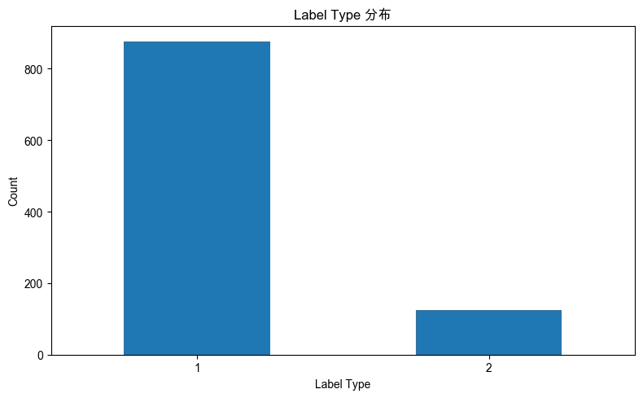

```python
# label_type 分布
print("label_type 分布:")
print(df['label_type'].value_counts().sort_index())

plt.figure(figsize=(8, 5))
df['label_type'].value_counts().sort_index().plot(kind='bar')
plt.title('Label Type 分布')
plt.xlabel('Label Type')
plt.ylabel('Count')
plt.xticks(rotation=0)
plt.tight_layout()
plt.show()
```

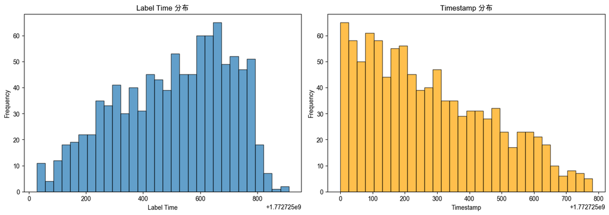

```
Label Time 范围: 1772725027 - 1772725910
Timestamp 范围: 1772725000 - 1772725781
```

```python
# 时间戳分析
fig, axes = plt.subplots(1, 2, figsize=(14, 5))

# label_time 分布
axes[0].hist(df['label_time'], bins=30, edgecolor='black', alpha=0.7)
axes[0].set_title('Label Time 分布')
axes[0].set_xlabel('Label Time')
axes[0].set_ylabel('Frequency')

# timestamp 分布
axes[1].hist(df['timestamp'], bins=30, edgecolor='black', alpha=0.7, color='orange')
axes[1].set_title('Timestamp 分布')
axes[1].set_xlabel('Timestamp')
axes[1].set_ylabel('Frequency')

plt.tight_layout()
plt.show()

print(f"Label Time 范围: {df['label_time'].min()} - {df['label_time'].max()}")
print(f"Timestamp 范围: {df['timestamp'].min()} - {df['timestamp'].max()}")
```

## 3. User Int Features 分析 (46列)

- 标量 int64: user_int_feats_{1,3,4,48-59,82,86,92-109} (35列)
- 数组 list: user_int_feats_{15, 60, 62-66, 80, 89-91} (11列)

```python
# 获取所有 User Int Features 列
user_int_cols = [col for col in df.columns if col.startswith('user_int_feats_')]
print(f"User Int Features 总数: {len(user_int_cols)}")

# 区分数值型和数组型
user_int_scalar_cols = []
user_int_array_cols = []

for col in user_int_cols:
    if df[col].dtype == 'object':  # list/array 类型
        user_int_array_cols.append(col)
    else:
        user_int_scalar_cols.append(col)

print(f"\n标量型 (int64): {len(user_int_scalar_cols)} 列")
print(f"数组型 (list<int64>): {len(user_int_array_cols)} 列")
print(f"\n数组型列: {user_int_array_cols}")
```

```
User Int Features 总数: 46

标量型 (int64): 35 列
数组型 (list<int64>): 11 列

数组型列: ['user_int_feats_15', 'user_int_feats_60', 'user_int_feats_62', 'user_int_feats_63', 'user_int_feats_64', 'user_int_feats_65', 'user_int_feats_66', 'user_int_feats_80', 'user_int_feats_89', 'user_int_feats_90', 'user_int_feats_91']
```

```python
# 标量型 User Int Features 统计
if user_int_scalar_cols:
    print("标量型 User Int Features 统计:")
    print(df[user_int_scalar_cols].describe())
```

```
标量型 User Int Features 统计:
       user_int_feats_1  user_int_feats_3  user_int_feats_4  \
count       1000.000000        970.000000        970.000000
mean           3.381000        987.556701        498.813402
std            1.170132        517.050625        299.396295
min            1.000000          9.000000          1.000000
25%            4.000000        609.500000        245.250000
50%            4.000000        957.000000        496.500000
75%            4.000000       1446.750000        758.000000
max            4.000000       1839.000000        986.000000

       user_int_feats_48  user_int_feats_49  user_int_feats_50  \
count         998.000000         993.000000         996.000000
mean           58.006012           1.582075           0.997992
std            27.556961           0.493466           0.044789
min             3.000000           1.000000           0.000000
25%            34.000000           1.000000           1.000000
50%            60.000000           2.000000           1.000000
75%            82.000000           2.000000           1.000000
max            99.000000           2.000000           1.000000

       user_int_feats_51  user_int_feats_52  user_int_feats_53  \
count         999.000000         999.000000         999.000000
mean           56.157157          93.855856         288.541542
std             3.581337          56.341388         165.367230
min            40.000000           5.000000           3.000000
25%            56.000000          41.000000         136.500000
50%            56.000000          98.000000         307.000000
75%            56.000000         152.000000         419.000000
max           150.000000         174.000000         557.000000

       user_int_feats_54  user_int_feats_55  user_int_feats_56  \
count         632.000000         981.000000         981.000000
mean         1476.783228          29.681957         752.657492
std           838.695602           9.649298         405.578583
min             3.000000           8.000000           1.000000
25%           730.750000          19.000000         425.000000
50%          1483.500000          34.000000         731.000000
75%          2249.000000          41.000000        1113.000000
max          2843.000000          41.000000        1434.000000
```

[output cut: 65 more lines]

```
min              1.000000            1.000000            1.000000
25%              2.000000            2.000000            1.000000
50%              2.000000            2.000000            1.000000
75%              3.000000            2.000000            1.000000
max              3.000000            3.000000            2.000000

       user_int_feats_108  user_int_feats_109
count          484.000000          146.000000
mean             5.454545            2.993151
std              1.689083            2.367879
min              2.000000            1.000000
25%              4.750000            1.000000
50%              6.000000            1.000000
75%              7.000000            5.000000
max              7.000000            7.000000
```

```python
# 数组型 User Int Features 分析
def analyze_array_feature(df, col):
    """分析数组型特征的统计信息"""
    lengths = df[col].apply(lambda x: len(x) if isinstance(x, (list, np.ndarray)) else 0)
    print(f"\n{col}:")
    print(f"  - 数组长度范围: {lengths.min()} - {lengths.max()}")
    print(f"  - 平均长度: {lengths.mean():.2f}")
    print(f"  - 长度中位数: {lengths.median():.2f}")
    return lengths

print("数组型 User Int Features 分析:")
user_int_lengths = {}
for col in user_int_array_cols:
    user_int_lengths[col] = analyze_array_feature(df, col)
```

```
数组型 User Int Features 分析:

user_int_feats_15:
  - 数组长度范围: 0 - 13
  - 平均长度: 3.23
  - 长度中位数: 3.00

user_int_feats_60:
  - 数组长度范围: 0 - 2
  - 平均长度: 0.62
  - 长度中位数: 0.00

user_int_feats_62:
  - 数组长度范围: 0 - 5
  - 平均长度: 2.11
  - 长度中位数: 2.00

user_int_feats_63:
  - 数组长度范围: 0 - 11
  - 平均长度: 2.56
  - 长度中位数: 2.00

user_int_feats_64:
  - 数组长度范围: 0 - 18
  - 平均长度: 3.82
  - 长度中位数: 3.00

user_int_feats_65:
  - 数组长度范围: 0 - 49
  - 平均长度: 5.71
  - 长度中位数: 4.00

user_int_feats_66:
  - 数组长度范围: 0 - 66
  - 平均长度: 7.14
  - 长度中位数: 5.00

user_int_feats_80:
  - 数组长度范围: 0 - 5
  - 平均长度: 1.16
  - 长度中位数: 1.00

user_int_feats_89:
  - 数组长度范围: 0 - 10
  - 平均长度: 9.45
  - 长度中位数: 10.00

user_int_feats_90:
  - 数组长度范围: 0 - 10
  - 平均长度: 9.09
  - 长度中位数: 10.00

user_int_feats_91:
  - 数组长度范围: 0 - 10
  - 平均长度: 5.50
  - 长度中位数: 10.00
```

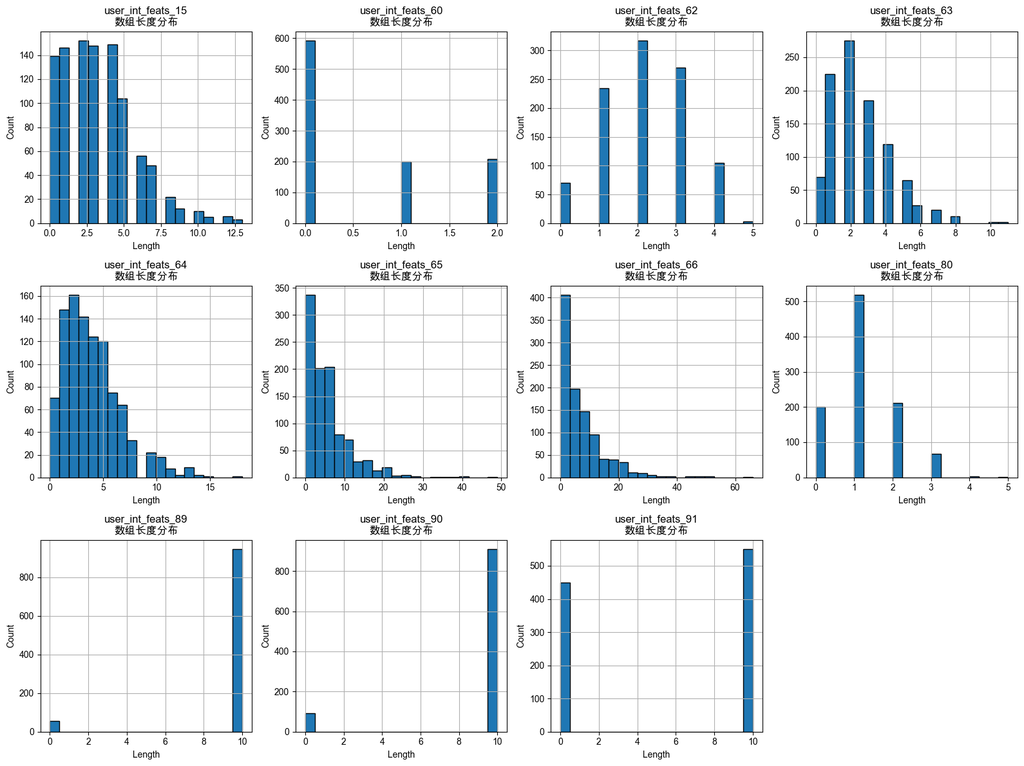

```python
# 可视化数组长度分布
if user_int_array_cols:
    fig, axes = plt.subplots(3, 4, figsize=(16, 12))
    axes = axes.flatten()

    for idx, col in enumerate(user_int_array_cols):
        if idx < len(axes):
            user_int_lengths[col].hist(bins=20, ax=axes[idx], edgecolor='black')
            axes[idx].set_title(f'{col}\n数组长度分布')
            axes[idx].set_xlabel('Length')
            axes[idx].set_ylabel('Count')

    # 隐藏多余的子图
    for idx in range(len(user_int_array_cols), len(axes)):
        axes[idx].set_visible(False)

    plt.tight_layout()
    plt.show()
```

## 4. User Dense Features 分析 (10列)

包括: user_dense_feats_{61-66, 87, 89-91}

```python
# 获取 User Dense Features 列
user_dense_cols = [col for col in df.columns if col.startswith('user_dense_feats_')]
print(f"User Dense Features 总数: {len(user_dense_cols)}")
print(f"列名: {user_dense_cols}")
```

```
User Dense Features 总数: 10
列名: ['user_dense_feats_61', 'user_dense_feats_62', 'user_dense_feats_63', 'user_dense_feats_64', 'user_dense_feats_65', 'user_dense_feats_66', 'user_dense_feats_87', 'user_dense_feats_89', 'user_dense_feats_90', 'user_dense_feats_91']
```

```python
# 分析 Dense Features
print("User Dense Features 分析:")
user_dense_lengths = {}
user_dense_stats = {}

for col in user_dense_cols:
    # 数组长度
    lengths = df[col].apply(lambda x: len(x) if isinstance(x, (list, np.ndarray)) else 0)
    user_dense_lengths[col] = lengths

    # 展开所有值进行统计
    all_values = []
    for arr in df[col]:
        if isinstance(arr, (list, np.ndarray)):
            all_values.extend(arr)

    if all_values:
        user_dense_stats[col] = {
            'count': len(all_values),
            'mean': np.mean(all_values),
            'std': np.std(all_values),
            'min': np.min(all_values),
            'max': np.max(all_values),
            'length_mean': lengths.mean()
        }

    print(f"\n{col}:")
    print(f"  - 数组长度范围: {lengths.min()} - {lengths.max()}")
    print(f"  - 平均长度: {lengths.mean():.2f}")
    if all_values:
        print(f"  - 数值范围: {np.min(all_values):.4f} - {np.max(all_values):.4f}")
        print(f"  - 数值均值: {np.mean(all_values):.4f}")
```

```
User Dense Features 分析:

user_dense_feats_61:
  - 数组长度范围: 0 - 256
  - 平均长度: 255.49
  - 数值范围: -0.2511 - 0.2013
  - 数值均值: -0.0011

user_dense_feats_62:
  - 数组长度范围: 0 - 5
  - 平均长度: 2.11
  - 数值范围: 32.0000 - 4954893.0000
  - 数值均值: 136400.6562

user_dense_feats_63:
  - 数组长度范围: 0 - 11
  - 平均长度: 2.56
  - 数值范围: 6.0000 - 4860850.0000
  - 数值均值: 128705.3281

user_dense_feats_64:
  - 数组长度范围: 0 - 18
  - 平均长度: 3.82
  - 数值范围: 23.0000 - 12762341.0000
  - 数值均值: 121708.9297

user_dense_feats_65:
  - 数组长度范围: 0 - 49
  - 平均长度: 5.71
  - 数值范围: 5.0000 - 18401112.0000
  - 数值均值: 146881.6719

user_dense_feats_66:
  - 数组长度范围: 0 - 66
  - 平均长度: 7.14
  - 数值范围: 5.0000 - 18401112.0000
  - 数值均值: 198935.5625

user_dense_feats_87:
  - 数组长度范围: 0 - 320
  - 平均长度: 315.20
  - 数值范围: -0.6842 - 0.6844
  - 数值均值: -0.0040

user_dense_feats_89:
  - 数组长度范围: 0 - 10
  - 平均长度: 9.45
  - 数值范围: -0.7245 - 0.9087
  - 数值均值: -0.0000

user_dense_feats_90:
  - 数组长度范围: 0 - 10
  - 平均长度: 9.09
  - 数值范围: -0.7238 - 0.8788
  - 数值均值: -0.0001

user_dense_feats_91:
  - 数组长度范围: 0 - 10
  - 平均长度: 5.50
  - 数值范围: -0.7805 - 0.9076
  - 数值均值: 0.0000
```

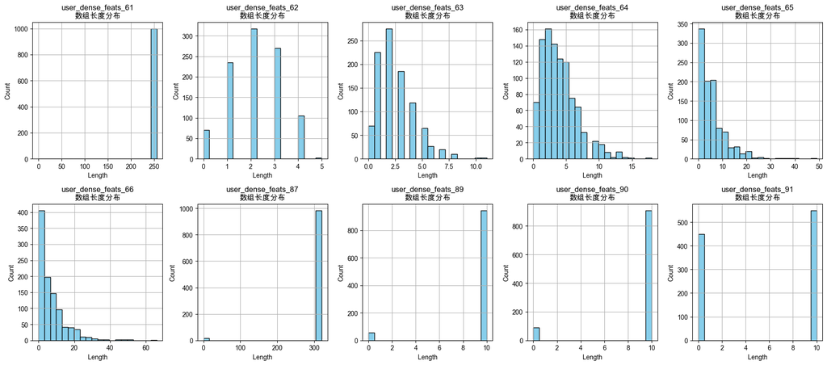

```python
# 可视化 Dense Features 的数组长度分布
fig, axes = plt.subplots(2, 5, figsize=(18, 8))
axes = axes.flatten()

for idx, col in enumerate(user_dense_cols):
    user_dense_lengths[col].hist(bins=20, ax=axes[idx], edgecolor='black', color='skyblue')
    axes[idx].set_title(f'{col}\n数组长度分布')
    axes[idx].set_xlabel('Length')
    axes[idx].set_ylabel('Count')

plt.tight_layout()
plt.show()
```

## 5. Item Int Features 分析 (14列)

- 标量 int64: item_int_feats_{5-10, 12-13, 16, 81, 83-85} (13列)
- 数组 list: item_int_feats_{11} (1列)

```python
# 获取 Item Int Features 列
item_int_cols = [col for col in df.columns if col.startswith('item_int_feats_')]
print(f"Item Int Features 总数: {len(item_int_cols)}")

# 区分数值型和数组型
item_int_scalar_cols = []
item_int_array_cols = []

for col in item_int_cols:
    if df[col].dtype == 'object':  # list/array 类型
        item_int_array_cols.append(col)
    else:
        item_int_scalar_cols.append(col)

print(f"\n标量型 (int64): {len(item_int_scalar_cols)} 列")
print(f"数组型 (list<int64>): {len(item_int_array_cols)} 列")
print(f"\n数组型列: {item_int_array_cols}")
```

```
Item Int Features 总数: 14

标量型 (int64): 13 列
数组型 (list<int64>): 1 列

数组型列: ['item_int_feats_11']
```

```python
# 标量型 Item Int Features 统计
if item_int_scalar_cols:
    print("标量型 Item Int Features 统计:")
    print(df[item_int_scalar_cols].describe())
```

```
标量型 Item Int Features 统计:
       item_int_feats_5  item_int_feats_6  item_int_feats_7  item_int_feats_8  \
count        998.000000        998.000000        998.000000        998.000000
mean         118.451904        419.073146       1052.865731        463.712425
std           78.573868        245.595675        745.350627        667.482152
min            4.000000          0.000000          0.000000         -1.000000
25%           52.000000        210.750000        399.000000          0.000000
50%          128.000000        412.000000        939.000000          0.000000
75%          158.000000        625.000000       1667.000000        794.250000
max          325.000000        977.000000       2806.000000       2431.000000

       item_int_feats_9  item_int_feats_10  item_int_feats_12  \
count        998.000000         998.000000         998.000000
mean          21.171343         150.007014        1039.380762
std            9.573016          89.762156         779.928909
min            3.000000           2.000000           0.000000
25%           14.000000          75.000000         296.250000
50%           23.000000         134.000000        1031.000000
75%           31.000000         210.000000        1769.000000
max           37.000000         309.000000        2777.000000

       item_int_feats_13  item_int_feats_16  item_int_feats_81  \
count         998.000000         998.000000         998.000000
mean            4.456914       12356.101202           0.508016
std             2.508091        8037.689149           0.766288
min             1.000000           2.000000           0.000000
25%             2.000000        5931.250000           0.000000
50%             4.000000       11347.000000           0.000000
75%             6.000000       18028.500000           1.000000
max             8.000000       35259.000000           2.000000

       item_int_feats_83  item_int_feats_84  item_int_feats_85
count         168.000000         168.000000         168.000000
mean           17.595238         131.130952         439.815476
std             9.198567          67.733589         303.705038
min             1.000000           3.000000           4.000000
25%             8.000000          79.000000         140.000000
50%            15.500000         146.000000         429.000000
75%            28.000000         184.000000         700.500000
max            31.000000         226.000000        1001.000000
```

```python
# 数组型 Item Int Features 分析
if item_int_array_cols:
    print("数组型 Item Int Features 分析:")
    for col in item_int_array_cols:
        analyze_array_feature(df, col)
```

```
数组型 Item Int Features 分析:

item_int_feats_11:
  - 数组长度范围: 0 - 20
  - 平均长度: 2.09
  - 长度中位数: 1.00
```

## 6. Domain Sequence Features 分析 (45列)

来自 4 个行为域的序列特征:

- domain_a_seq_{38-46}: 9 列
- domain_b_seq_{67-79, 88}: 14 列
- domain_c_seq_{27-37, 47}: 12 列
- domain_d_seq_{17-26}: 10 列

```python
# 获取 Domain Sequence Features 列
domain_a_cols = [col for col in df.columns if col.startswith('domain_a_seq_')]
domain_b_cols = [col for col in df.columns if col.startswith('domain_b_seq_')]
domain_c_cols = [col for col in df.columns if col.startswith('domain_c_seq_')]
domain_d_cols = [col for col in df.columns if col.startswith('domain_d_seq_')]

all_domain_cols = domain_a_cols + domain_b_cols + domain_c_cols + domain_d_cols

print("Domain Sequence Features 分布:")
print(f"  Domain A: {len(domain_a_cols)} 列")
print(f"  Domain B: {len(domain_b_cols)} 列")
print(f"  Domain C: {len(domain_c_cols)} 列")
print(f"  Domain D: {len(domain_d_cols)} 列")
print(f"  总计: {len(all_domain_cols)} 列")
```

```
Domain Sequence Features 分布:
  Domain A: 9 列
  Domain B: 14 列
  Domain C: 12 列
  Domain D: 10 列
  总计: 45 列
```

```python
# 分析每个 Domain 的序列长度
def analyze_domain_sequences(df, domain_cols, domain_name):
    """分析某个 Domain 的所有序列特征"""
    print(f"\n{'='*50}")
    print(f"{domain_name} 分析")
    print(f"{'='*50}")

    length_stats = {}
    for col in domain_cols:
        lengths = df[col].apply(lambda x: len(x) if isinstance(x, (list, np.ndarray)) else 0)
        length_stats[col] = {
            'min': lengths.min(),
            'max': lengths.max(),
            'mean': lengths.mean(),
            'median': lengths.median()
        }

    # 转换为 DataFrame 展示
    stats_df = pd.DataFrame(length_stats).T
    print("\n序列长度统计:")
    print(stats_df)

    return length_stats

domain_a_stats = analyze_domain_sequences(df, domain_a_cols, "Domain A")
domain_b_stats = analyze_domain_sequences(df, domain_b_cols, "Domain B")
domain_c_stats = analyze_domain_sequences(df, domain_c_cols, "Domain C")
domain_d_stats = analyze_domain_sequences(df, domain_d_cols, "Domain D")
```

```
==================================================
Domain A 分析
==================================================

序列长度统计:
                 min     max     mean  median
domain_a_seq_38  0.0  1888.0  701.086   577.5
domain_a_seq_39  0.0  1888.0  701.086   577.5
domain_a_seq_40  0.0  1888.0  701.086   577.5
domain_a_seq_41  0.0  1888.0  701.086   577.5
domain_a_seq_42  0.0  1888.0  701.086   577.5
domain_a_seq_43  0.0  1888.0  701.086   577.5
domain_a_seq_44  0.0  1888.0  701.086   577.5
domain_a_seq_45  0.0  1888.0  701.086   577.5
domain_a_seq_46  0.0  1888.0  701.086   577.5

==================================================
Domain B 分析
==================================================

序列长度统计:
                 min     max     mean  median
domain_b_seq_67  0.0  1952.0  570.758   405.0
domain_b_seq_68  0.0  1952.0  570.758   405.0
domain_b_seq_69  0.0  1952.0  570.758   405.0
domain_b_seq_70  0.0  1952.0  570.758   405.0
domain_b_seq_71  0.0  1952.0  570.758   405.0
domain_b_seq_72  0.0  1952.0  570.758   405.0
domain_b_seq_73  0.0  1952.0  570.758   405.0
domain_b_seq_74  0.0  1952.0  570.758   405.0
domain_b_seq_75  0.0  1952.0  570.758   405.0
domain_b_seq_76  0.0  1952.0  570.758   405.0
domain_b_seq_77  0.0  1952.0  570.758   405.0
domain_b_seq_78  0.0  1952.0  570.758   405.0
domain_b_seq_79  0.0  1952.0  570.758   405.0
domain_b_seq_88  0.0  1952.0  570.758   405.0

==================================================
Domain C 分析
==================================================
```

[output cut: 17 more lines]

```
Domain D 分析
==================================================

序列长度统计:
                 min     max      mean  median
domain_d_seq_17  0.0  3951.0  1099.859  1035.5
domain_d_seq_18  0.0  3951.0  1099.859  1035.5
domain_d_seq_19  0.0  3951.0  1099.859  1035.5
domain_d_seq_20  0.0  3951.0  1099.859  1035.5
domain_d_seq_21  0.0  3951.0  1099.859  1035.5
domain_d_seq_22  0.0  3951.0  1099.859  1035.5
domain_d_seq_23  0.0  3951.0  1099.859  1035.5
domain_d_seq_24  0.0  3951.0  1099.859  1035.5
domain_d_seq_25  0.0  3951.0  1099.859  1035.5
domain_d_seq_26  0.0  3951.0  1099.859  1035.5
```

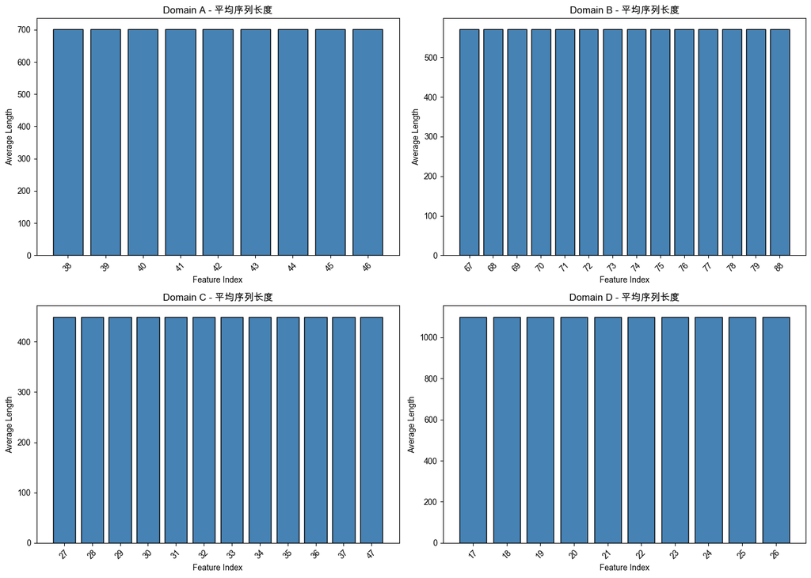

```python
# 可视化各 Domain 的平均序列长度
fig, axes = plt.subplots(2, 2, figsize=(14, 10))

domains = [
    ("Domain A", domain_a_cols, domain_a_stats),
    ("Domain B", domain_b_cols, domain_b_stats),
    ("Domain C", domain_c_cols, domain_c_stats),
    ("Domain D", domain_d_cols, domain_d_stats)
]

for idx, (name, cols, stats) in enumerate(domains):
    ax = axes[idx // 2, idx % 2]
    means = [stats[col]['mean'] for col in cols]
    ax.bar(range(len(cols)), means, color='steelblue', edgecolor='black')
    ax.set_title(f'{name} - 平均序列长度')
    ax.set_xlabel('Feature Index')
    ax.set_ylabel('Average Length')
    ax.set_xticks(range(len(cols)))
    ax.set_xticklabels([col.split('_')[-1] for col in cols], rotation=45)

plt.tight_layout()
plt.show()
```

## 7. 综合数据可视化

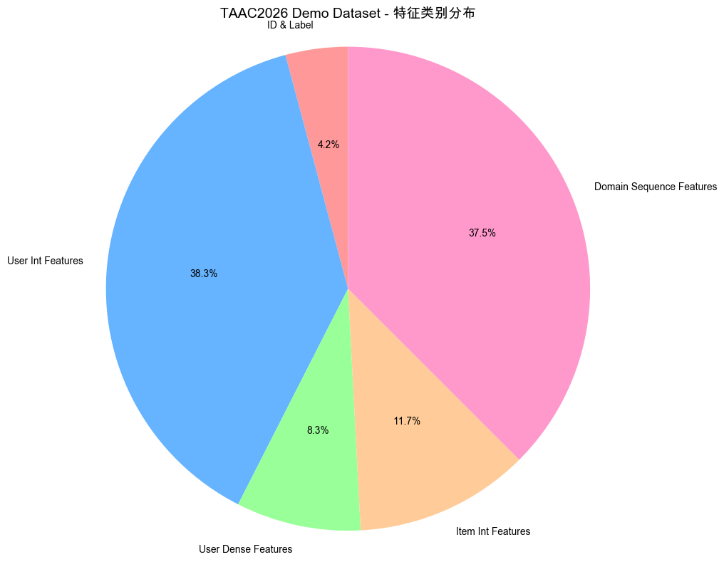

```
特征类别统计:
  ID & Label: 5 列
  User Int Features: 46 列
  User Dense Features: 10 列
  Item Int Features: 14 列
  Domain Sequence Features: 45 列
```

```python
# 特征类别分布饼图
feature_categories = {
    'ID & Label': 5,
    'User Int Features': 46,
    'User Dense Features': 10,
    'Item Int Features': 14,
    'Domain Sequence Features': 45
}

plt.figure(figsize=(10, 8))
colors = ['#ff9999', '#66b3ff', '#99ff99', '#ffcc99', '#ff99cc']
plt.pie(feature_categories.values(), labels=feature_categories.keys(),
        autopct='%1.1f%%', startangle=90, colors=colors)
plt.title('TAAC2026 Demo Dataset - 特征类别分布', fontsize=14)
plt.axis('equal')
plt.tight_layout()
plt.show()

print("特征类别统计:")
for cat, count in feature_categories.items():
    print(f"  {cat}: {count} 列")
```

```
数据类型分布:
object     67
float64    47
int64       5
int32       1
Name: count, dtype: int64
```

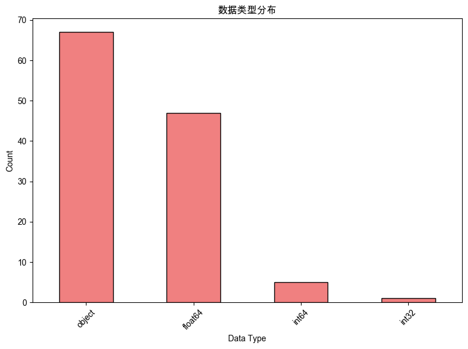

```python
# 数据类型分布
dtype_counts = df.dtypes.value_counts()
print("数据类型分布:")
print(dtype_counts)

plt.figure(figsize=(8, 6))
dtype_counts.plot(kind='bar', color='lightcoral', edgecolor='black')
plt.title('数据类型分布')
plt.xlabel('Data Type')
plt.ylabel('Count')
plt.xticks(rotation=45)
plt.tight_layout()
plt.show()
```

```python
# 用户-物品交互分析
print("用户-物品交互分析:")
print(f"总交互数: {len(df)}")
print(f"唯一用户数: {df['user_id'].nunique()}")
print(f"唯一物品数: {df['item_id'].nunique()}")
print(f"平均每个用户的交互数: {len(df) / df['user_id'].nunique():.2f}")
print(f"平均每个物品的交互数: {len(df) / df['item_id'].nunique():.2f}")

# 用户交互数分布
user_interactions = df['user_id'].value_counts()
print(f"\n用户交互数分布:")
print(f"  最少交互数: {user_interactions.min()}")
print(f"  最多交互数: {user_interactions.max()}")
print(f"  平均交互数: {user_interactions.mean():.2f}")

# 物品被交互数分布
item_interactions = df['item_id'].value_counts()
print(f"\n物品被交互数分布:")
print(f"  最少被交互数: {item_interactions.min()}")
print(f"  最多被交互数: {item_interactions.max()}")
print(f"  平均被交互数: {item_interactions.mean():.2f}")
```

```
用户-物品交互分析:
总交互数: 1000
唯一用户数: 1000
唯一物品数: 837
平均每个用户的交互数: 1.00
平均每个物品的交互数: 1.19

用户交互数分布:
  最少交互数: 1
  最多交互数: 1
  平均交互数: 1.00

物品被交互数分布:
  最少被交互数: 1
  最多被交互数: 17
  平均被交互数: 1.19
```

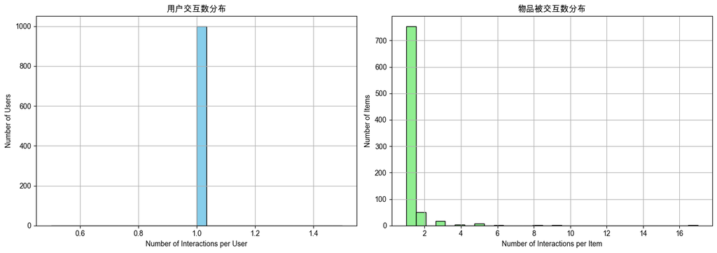

```python
# 可视化用户和物品的交互分布
fig, axes = plt.subplots(1, 2, figsize=(14, 5))

# 用户交互数分布
user_interactions.hist(bins=30, ax=axes[0], edgecolor='black', color='skyblue')
axes[0].set_title('用户交互数分布')
axes[0].set_xlabel('Number of Interactions per User')
axes[0].set_ylabel('Number of Users')

# 物品被交互数分布
item_interactions.hist(bins=30, ax=axes[1], edgecolor='black', color='lightgreen')
axes[1].set_title('物品被交互数分布')
axes[1].set_xlabel('Number of Interactions per Item')
axes[1].set_ylabel('Number of Items')

plt.tight_layout()
plt.show()
```

## 8. 数据质量检查

```python
# 检查缺失值
print("缺失值检查:")
missing_counts = df.isnull().sum()
missing_cols = missing_counts[missing_counts > 0]

if len(missing_cols) > 0:
    print(f"有缺失值的列数: {len(missing_cols)}")
    print(missing_cols)
else:
    print("✓ 没有缺失值")

# 检查重复行（只针对可哈希的列，排除数组类型）
hashable_cols = [col for col in df.columns if df[col].dtype != 'object']
duplicate_count = df[hashable_cols].duplicated().sum()
print(f"\n重复行数 (基于标量列): {duplicate_count}")

# ID & Label 列的空值检查（根据文档，这5列应该没有空值）
print("\nID & Label 列空值检查:")
for col in id_label_cols:
    null_count = df[col].isnull().sum()
    print(f"  {col}: {null_count} 个空值{' ✓' if null_count == 0 else ''}")
```

```
缺失值检查:
有缺失值的列数: 114
user_int_feats_3      30
user_int_feats_4      30
user_int_feats_15    139
user_int_feats_48      2
user_int_feats_49      7
                    ...
domain_d_seq_22       80
domain_d_seq_23       80
domain_d_seq_24       80
domain_d_seq_25       80
domain_d_seq_26       80
Length: 114, dtype: int64

重复行数 (基于标量列): 0

ID & Label 列空值检查:
  user_id: 0 个空值 ✓
  item_id: 0 个空值 ✓
  label_type: 0 个空值 ✓
  label_time: 0 个空值 ✓
  timestamp: 0 个空值 ✓
```

## 9. 总结

本 Notebook 对 TAAC2026 Demo Dataset 进行了全面的探索性数据分析，包括:

1. **数据加载与基本信息**: 成功加载了 1000 条样本，共 120 列特征
2. **ID & Label 分析**:
   - 1000 个唯一用户，837 个唯一物品
   - 每个用户平均 1.00 次交互（用户无重复交互）
   - 每个物品平均 1.19 次交互
   - Label Type: 1=876条(87.6%), 2=124条(12.4%)
   - Label Time 范围: 1772725027 - 1772725910
   - Timestamp 范围: 1772725000 - 1772725781
3. **User Int Features**: 分析了 46 列用户整数特征（35列标量 + 11列数组）
4. **User Dense Features**: 分析了 10 列用户稠密特征（浮点数组）
5. **Item Int Features**: 分析了 14 列物品整数特征（13列标量 + 1列数组）
6. **Domain Sequence Features**: 分析了 45 列跨域序列特征
7. **数据可视化**: 展示了特征分布、交互模式等
8. **数据质量**:
   - 114 列存在缺失值（主要是数组类型特征）
   - ID & Label 列无缺失值 ✓
   - 标量列无重复行

### 关键发现

- **数据集特点**: Demo数据集包含1000条独立用户交互，每个用户只有一条记录
- **特征丰富度**: 包含标量、数组、序列等多种模态特征，共120列
- **跨域行为**: 4个不同 Domain 的行为序列提供了丰富的跨域信息
- **数据质量**: ID & Label 核心字段完整，但大部分特征列存在缺失值
- **正负样本**: label_type 1 vs 2 的比例约为 7:1，样本有一定不平衡
- **时间窗口**: 数据集中在短时间内（约883秒时间窗口）
- **应用场景**: 适合冷启动推荐、跨域推荐等场景的特征工程探索